# summary-results-plots

2025-03-14

# 1 Scenario definitions

- Tree canopy
  - Population-based Scenario: AI: Increase by 10% in all zip codes
  - Targeted
    - Scenario AII1: Increase by 10% in zip codes in the lowest 1/5th of current TC cover (i.e. <=20th pctile)
    - Scenario AII2: Increase by 10% in zip codes in the highest 1/5th of the Social Vulnerability Index (i.e. >80th pctile)
    - Scenario AII3: Increase by 10% in zip codes in the highest 1/5th of hospitalization burden (i.e. >80th pctile)
  - Proportionate-universalism
    - Scenario AIII1: Increase by 10% for bottom 1/5th of current TC cover… down to 2% for top 1/5th
    - Scenario AIII2: Increase by 10% for top 1/5th of SVI … down to 2% for bottom 1/5th
    - Scenario AIII3: Increase by 10% for top 1/5th of hospitalization burden … down to 2% for bottom 1/5th
- Impervious surface cover
  - Population-based: Scenario BI: Decrease by 10% in all zip codes
  - Targeted
    - Scenario BII1: Decrease by 10% in zip codes in the highest 1/5th of current imperv cover (i.e. >80th pctile)
    - Scenario BII2: Decrease by 10% in zip codes in the highest 1/5th of the Social Vulnerability Index (i.e. >80th pctile)
    - Scenario BII3: Decrease by 10% in zip codes in the highest 1/5th of hospitalization burden (i.e. >80th pctile)
  - Proportionate-universalism
    - Scenario BIII1: Decrease by 10% for top 1/5th of current imperv cover … down to 2% for bottom 1/5th
    - Scenario BIII2: Decrease by 10% for top 1/5th of SVI … down to 2% for bottom 1/5th
    - Scenario BIII3: Decrease by 10% for top 1/5th of hospitalization burden … down to 2% for bottom 1/5th

# 2 Summary results (akin Table 2)

Similar to your current Table 2

## 2.1 Keeping denominator the same across scenarios

| scenario | scenario_intervention | scenario_type_7 | n_zcta | pop | attrib_hosps | n_cases_diff | ir_baseline | ir_alt | ird | irr |
| --- | --- | --- | --- | --- | --- | --- | --- | --- | --- | --- |
| AI | Tree | Pop. based | 1260 | 37107185 | 26.7 | 0.818 | 7.19e-07 | 6.97e-07 | -2.20e-08 | 0.969 |
| AII1 | Tree | Targeted 1 | 1260 | 37107185 | 26.7 | 0.042 | 7.19e-07 | 7.17e-07 | -1.00e-09 | 0.998 |
| AII2 | Tree | Targeted 2 | 1260 | 37107185 | 26.7 | 0.077 | 7.19e-07 | 7.16e-07 | -2.00e-09 | 0.997 |
| AII3 | Tree | Targeted 3 | 1260 | 37107185 | 26.7 | 0.105 | 7.19e-07 | 7.16e-07 | -3.00e-09 | 0.996 |
| AIII1 | Tree | Prop. Univ. 1 | 1260 | 37107185 | 26.7 | 0.305 | 7.19e-07 | 7.10e-07 | -8.00e-09 | 0.989 |
| AIII2 | Tree | Prop. Univ. 2 | 1260 | 37107185 | 26.7 | 0.402 | 7.19e-07 | 7.08e-07 | -1.10e-08 | 0.985 |
| AIII3 | Tree | Prop. Univ. 3 | 1260 | 37107185 | 26.7 | 0.475 | 7.19e-07 | 7.06e-07 | -1.30e-08 | 0.982 |
| BI | Imp | Pop. based | 1260 | 37107185 | 26.7 | 5.077 | 7.19e-07 | 5.82e-07 | -1.37e-07 | 0.810 |
| BII1 | Imp | Targeted 1 | 1260 | 37107185 | 26.7 | 1.619 | 7.19e-07 | 6.75e-07 | -4.40e-08 | 0.939 |
| BII2 | Imp | Targeted 2 | 1260 | 37107185 | 26.7 | 1.127 | 7.19e-07 | 6.88e-07 | -3.00e-08 | 0.958 |
| BII3 | Imp | Targeted 3 | 1260 | 37107185 | 26.7 | 1.256 | 7.19e-07 | 6.85e-07 | -3.40e-08 | 0.953 |
| BIII1 | Imp | Prop. Univ. 1 | 1260 | 37107185 | 26.7 | 3.697 | 7.19e-07 | 6.19e-07 | -1.00e-07 | 0.861 |
| BIII2 | Imp | Prop. Univ. 2 | 1260 | 37107185 | 26.7 | 3.158 | 7.19e-07 | 6.33e-07 | -8.50e-08 | 0.882 |
| BIII3 | Imp | Prop. Univ. 3 | 1260 | 37107185 | 26.7 | 3.131 | 7.19e-07 | 6.34e-07 | -8.40e-08 | 0.883 |

## 2.2 Restricting denominator to those zip codes intervened upon

| scenario | scenario_intervention | scenario_type_7 | n_zcta | pop | attrib_hosps | n_cases_diff | ir_baseline | ir_alt | ird | irr |
| --- | --- | --- | --- | --- | --- | --- | --- | --- | --- | --- |
| AI | Tree | Pop. based | 1258 | 37106796 | 26.7 | 0.818 | 7.190e-07 | 6.970e-07 | -2.20e-08 | 0.969 |
| AII1 | Tree | Targeted 1 | 252 | 8893539 | 6.0 | 0.042 | 6.750e-07 | 6.700e-07 | -5.00e-09 | 0.993 |
| AII2 | Tree | Targeted 2 | 252 | 8652011 | 10.3 | 0.077 | 1.193e-06 | 1.184e-06 | -9.00e-09 | 0.993 |
| AII3 | Tree | Targeted 3 | 252 | 10984778 | 58.3 | 0.105 | 5.308e-06 | 5.298e-06 | -1.00e-08 | 0.998 |
| AIII1 | Tree | Prop. Univ. 1 | 1258 | 37106796 | 26.7 | 0.305 | 7.190e-07 | 7.110e-07 | -8.00e-09 | 0.989 |
| AIII2 | Tree | Prop. Univ. 2 | 1258 | 37106796 | 26.7 | 0.402 | 7.190e-07 | 7.090e-07 | -1.10e-08 | 0.985 |
| AIII3 | Tree | Prop. Univ. 3 | 1258 | 37106796 | 26.7 | 0.475 | 7.190e-07 | 7.070e-07 | -1.30e-08 | 0.982 |
| BI | Imp | Pop. based | 1260 | 37107185 | 26.7 | 5.077 | 7.190e-07 | 5.820e-07 | -1.37e-07 | 0.810 |
| BII1 | Imp | Targeted 1 | 252 | 9578093 | 15.2 | 1.619 | 1.588e-06 | 1.419e-06 | -1.69e-07 | 0.894 |
| BII2 | Imp | Targeted 2 | 252 | 8652011 | 10.3 | 1.127 | 1.193e-06 | 1.063e-06 | -1.30e-07 | 0.891 |
| BII3 | Imp | Targeted 3 | 252 | 10984778 | 58.3 | 1.256 | 5.308e-06 | 5.193e-06 | -1.14e-07 | 0.978 |
| BIII1 | Imp | Prop. Univ. 1 | 1260 | 37107185 | 26.7 | 3.697 | 7.190e-07 | 6.190e-07 | -1.00e-07 | 0.861 |
| BIII2 | Imp | Prop. Univ. 2 | 1259 | 37107052 | 26.7 | 3.158 | 7.190e-07 | 6.340e-07 | -8.50e-08 | 0.882 |
| BIII3 | Imp | Prop. Univ. 3 | 1260 | 37107185 | 26.7 | 3.131 | 7.190e-07 | 6.340e-07 | -8.40e-08 | 0.883 |

## 2.3 Boxplots

Summarizing summary results over scenarios.

### 2.3.1 No change to denominator

#### 2.3.1.1 Difference in number of cases (absolute benefit)

Summarized by intervention targeting type. Both tree canopy and impervious surface

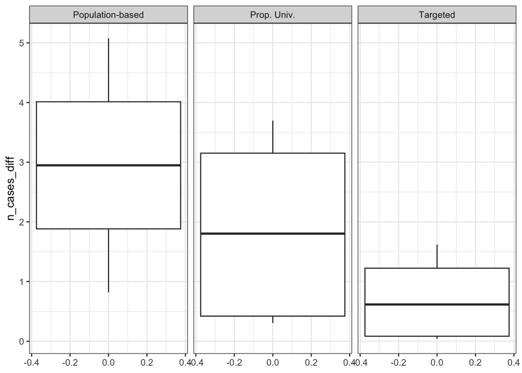

Summarized by greening strategy (tree canopy vs. impervious surface).

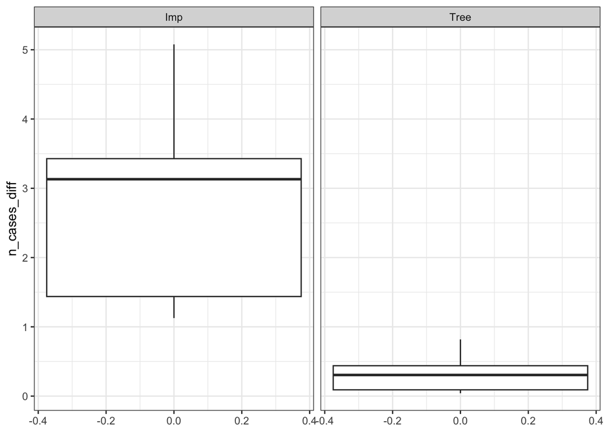

#### 2.3.1.2 IRD

Summarized by intervention targeting type

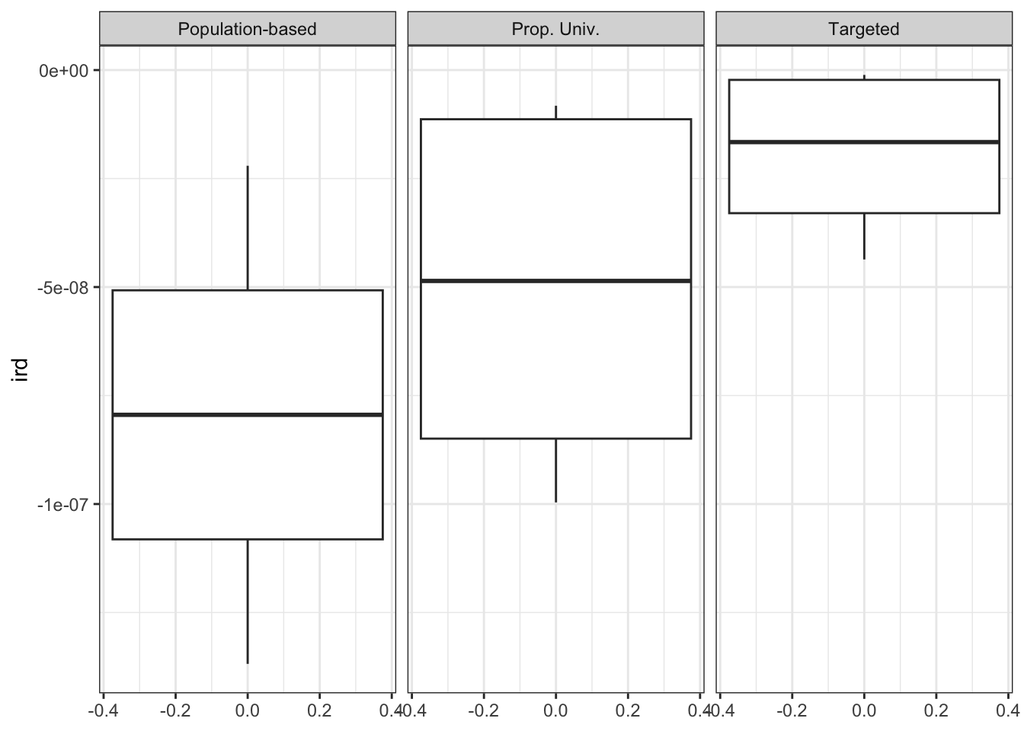

Summarized by greening strategy (tree canopy vs. impervious surface)

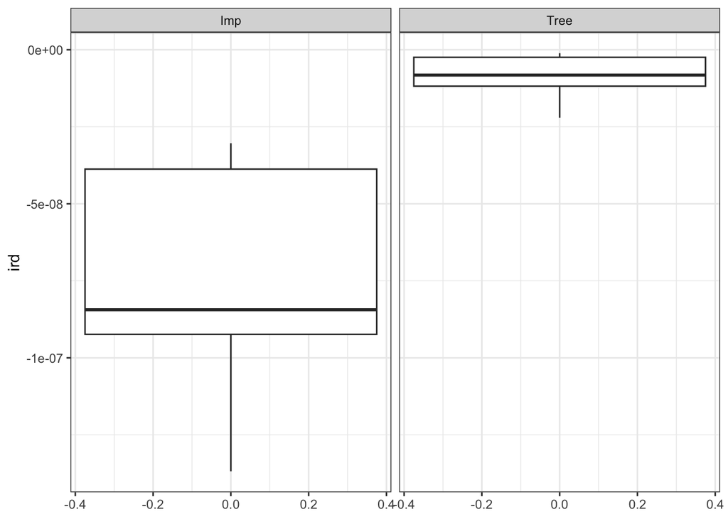

#### 2.3.1.3 IRR

Summarized by intervention targeting type. Both tree canopy and impervious surface

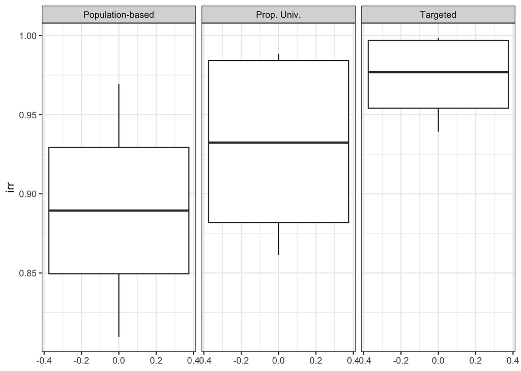

Summarized by greening strategy (tree canopy vs. impervious surface).

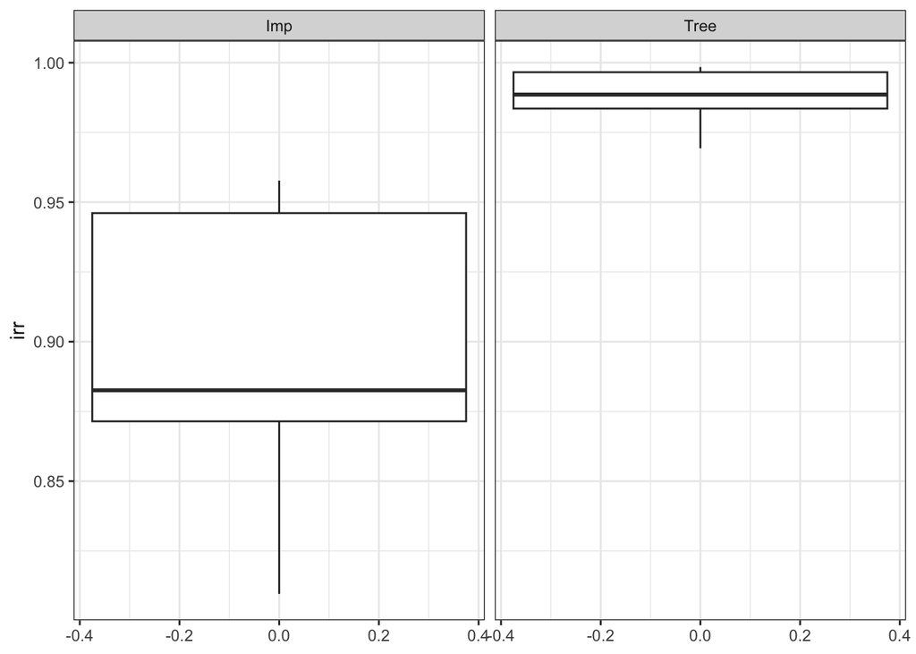

### 2.3.2 Restricting denominator

#### 2.3.2.1 Difference in number of cases (absolute benefit)

Summarized by intervention targeting type. Both tree canopy and impervious surface

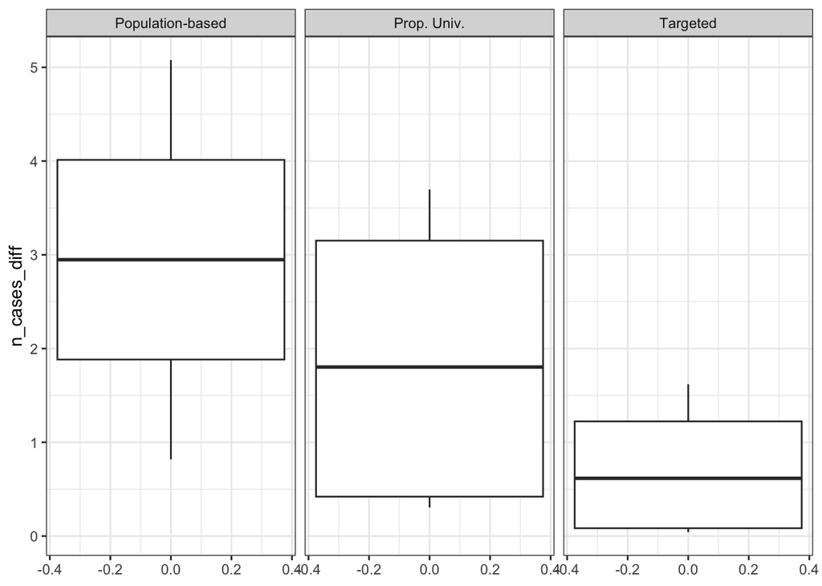

Summarized by greening strategy (tree canopy vs. impervious surface).

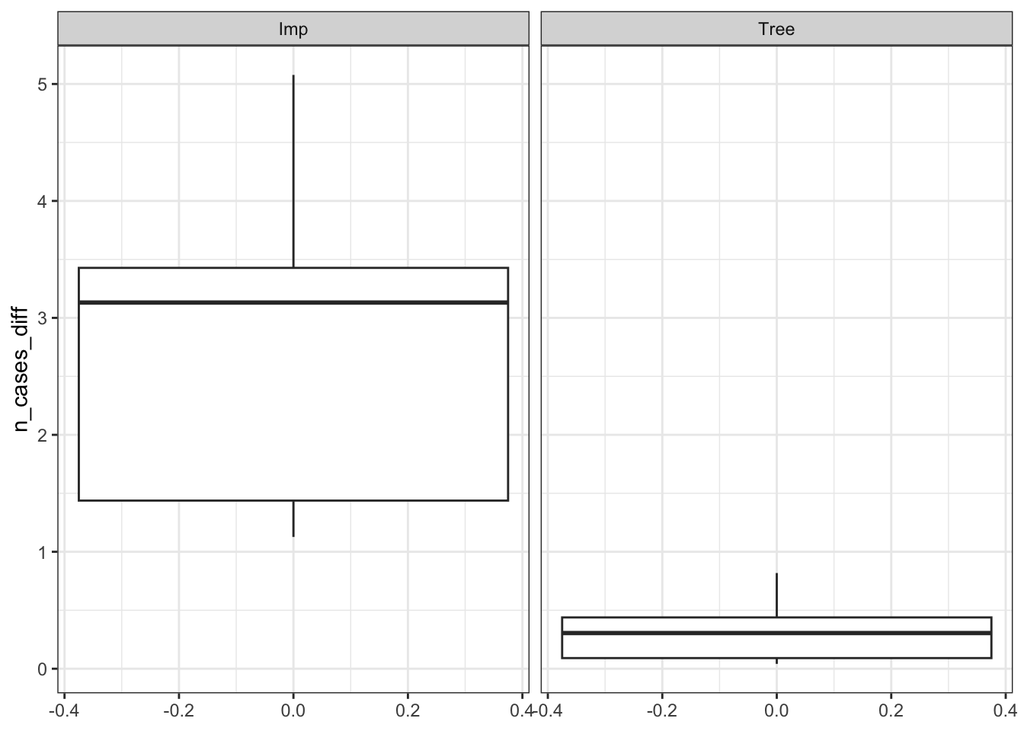

#### 2.3.2.2 IRD

Summarized by intervention targeting type. Both tree canopy and impervious surface

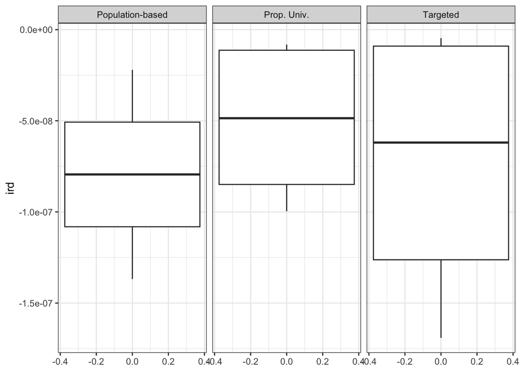

Summarized by greening strategy (tree canopy vs. impervious surface).

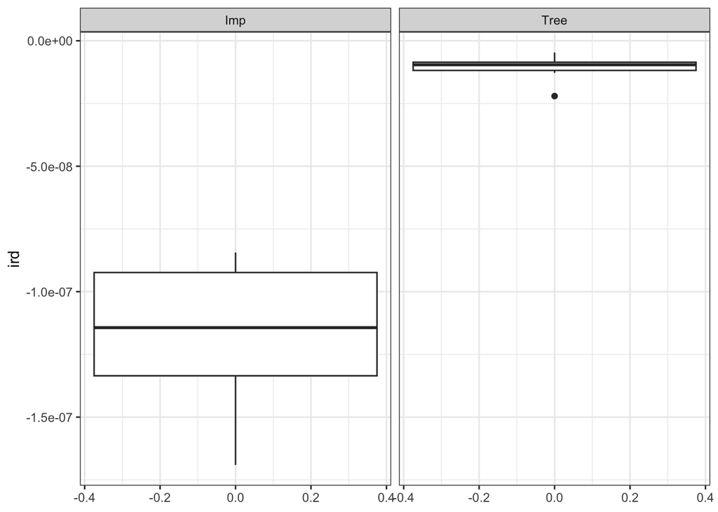

#### 2.3.2.3 IRR

Summarized by intervention targeting type. Both tree canopy and impervious surface

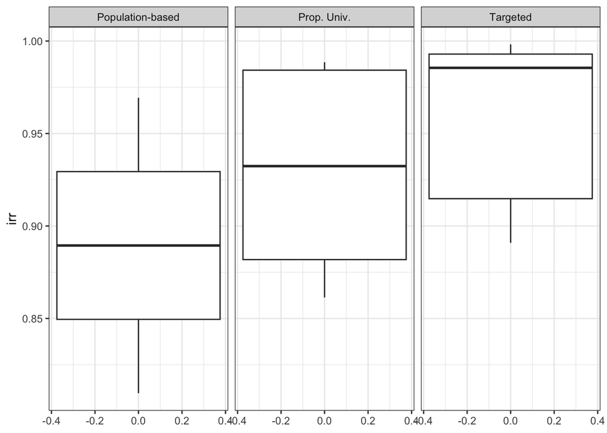

Summarized by greening strategy (tree canopy vs. impervious surface).

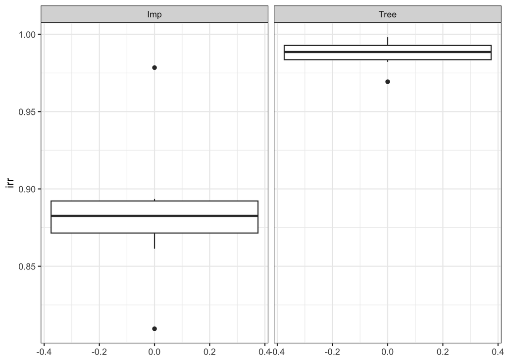